# DATA 607 Final Project

Jerald melukkaran

### Introduction

THis RMD includes the collection, cleaning and analysis of the data used for my DATA 607 Final project presentation. The topic for the presentation is a study on motorcycle accidents across the united states and how factors such as rider age, speed, alcohol involvement, time of day and use of protective gear influence motorcycle crash severity rates. The RMD will focus mainly on the code while the presentation will focus on the analytics and interpretations of the data

### Source

2023 Crash Report Sampling System (CRSS), by the National Highway Traffic Safety Administration (NHTSA):

- Complete root file : https://www.nhtsa.gov/file-downloads?p=nhtsa/downloads/CRSS/
- CRSS Public Use Files: https://www.nhtsa.gov/crash-data-systems/crash-report-sampling-system#how-the-information-is-used

Individual Datasets used

- Accident : For crash characteristics
- Vehicle : For vehicle characteristics and type
- Person : For information such as age, sex, restraint use, and injury severity
- Weather : For weather conditions during the crash
- Drimpair : For information on any possible impairments that might have contributed to the crash

USer manual : https://crashstats.nhtsa.dot.gov/Api/Public/ViewPublication/813707

```r
library(dplyr)
library(readr)
library(ggplot2)


accident <- read_csv("CRSS2023csv/accident.csv",
                     col_select = c(CASENUM, MAX_SEV, ALCOHOL, WEATHR_IM, HOUR_IM))

vehicle <- read_csv("CRSS2023csv/vehicle.csv",
                    col_select = c(CASENUM, TRAV_SP, VPICBODYCLASS, VSPD_LIM))

person <- read_csv("CRSS2023csv/person.csv",
                   col_select = c(CASENUM, AGE, ALC_RES, HELM_USE))

crash_data <- accident %>%
  left_join(vehicle, by = "CASENUM") %>%
  left_join(person, by = "CASENUM")

crash_data <- crash_data %>%
  mutate(
    VEHICLE_TYPE = case_when(
      VPICBODYCLASS %in% c(6, 12) ~ "Motorcycle",
      TRUE ~ "Other Vehicle"
    )
  )

glimpse(crash_data)
```

### Variables

##### Independant variables:

- From dataset Accident:
  - ALCHOHOL : Informs if alcohol was involved in the crash. 1 for yes, 2 for no.
  - WEATHER : For information on weather conditions present during the crash
- From dataset Vehicle:
  - TRAV_SP : Estimated Speed at the time of crash (quantitative) (from Vehicle)
  - VPICBODYCLASS : For the category of vehicle. This is 6 for standard motorcycles, and 12 for scooters (from Vehicle)
- From dataset Person:
  - AGE : Rider age (quantitative)
  - ALC_RES – Exact results of an alcohol test when applicable
  - HELM_USE – Whether the rider was wearing a helmet or other protective gear (categorical). 17 is the code for no helmet use while 5,16 and 19 determines the category of DOT compliance for the helmet being used

### Relevant summary statistics

```r
crash_data_clean <- crash_data %>%
  filter(MAX_SEV %in% 0:4) %>%
  mutate(
    MAX_SEV_LABEL = factor(MAX_SEV, levels = 0:4, labels = c(
      "No Injury",
      "Possible Injury",
      "Minor Injury",
      "Serious Injury",
      "Fatal"
    ))
  )

total_motorcycle <- crash_data_clean %>% filter(VEHICLE_TYPE == "Motorcycle") %>% nrow()
total_other <- crash_data_clean %>% filter(VEHICLE_TYPE == "Other Vehicle") %>% nrow()
```

##### Accident Severity (MAX_SEV)

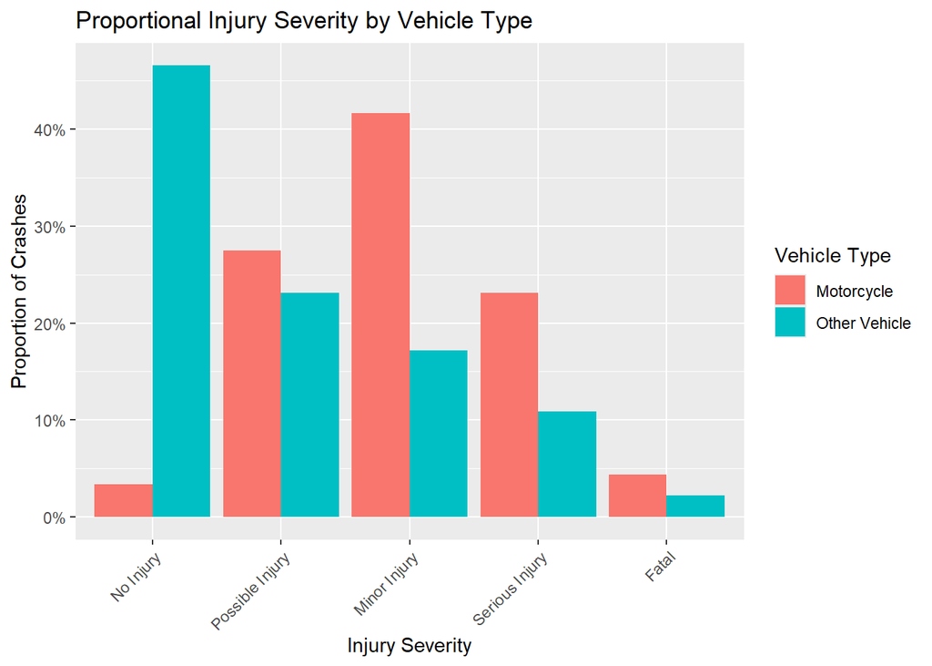

```r
severity_counts <- crash_data_clean %>%
  group_by(VEHICLE_TYPE, MAX_SEV_LABEL) %>%
  summarise(n = n(), .groups = "drop") %>%
  mutate(prop = case_when(
    VEHICLE_TYPE == "Motorcycle" ~ n / total_motorcycle,
    VEHICLE_TYPE == "Other Vehicle" ~ n / total_other
  ))
ggplot(severity_counts, aes(x = MAX_SEV_LABEL, y = prop, fill = VEHICLE_TYPE)) +
  geom_col(position = "dodge") +
  labs(
    title = "Proportional Injury Severity by Vehicle Type",
    x = "Injury Severity",
    y = "Proportion of Crashes",
    fill = "Vehicle Type"
  ) +
  scale_y_continuous(labels = scales::percent) +
  theme(axis.text.x = element_text(angle = 45, hjust = 1))
```

##### Age (AGE)

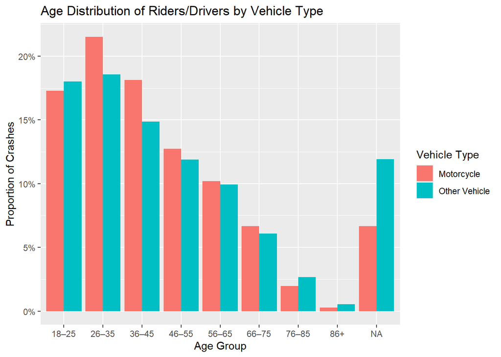

```r
 crash_data_age <- crash_data_clean %>%
   filter(!is.na(AGE), AGE <= 120) %>%
   mutate(
     AGE_GROUP = cut(
       AGE,
       breaks = c(17, 25, 35, 45, 55, 65, 75, 85, 120),
       labels = c("18–25", "26–35", "36–45", "46–55", "56–65", "66–75", "76–85", "86+"),
       right = TRUE
     )
   )

 crash_data_clean <- crash_data_clean %>%
   filter(!is.na(AGE), AGE <= 120)
 age_props <- crash_data_age %>%
   group_by(VEHICLE_TYPE, AGE_GROUP) %>%
   summarise(n = n(), .groups = "drop") %>%
   mutate(prop = case_when(
     VEHICLE_TYPE == "Motorcycle" ~ n / total_motorcycle,
     VEHICLE_TYPE == "Other Vehicle" ~ n / total_other
   ))

 ggplot(age_props, aes(x = AGE_GROUP, y = prop, fill = VEHICLE_TYPE)) +
   geom_col(position = "dodge") +
   labs(
     title = "Age Distribution of Riders/Drivers by Vehicle Type",
     x = "Age Group",
     y = "Proportion of Crashes",
     fill = "Vehicle Type"
   ) +
   scale_y_continuous(labels = scales::percent_format())
```

When looking at Age the trends seem similar with the age group of 18-36 having the highest proportions of crashes across all vehicle types

Scatter plot

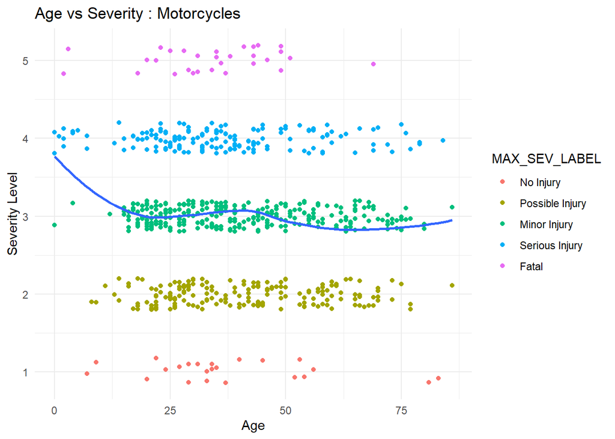

```r
crash_data_age_sampled <- crash_data_age %>%
  filter(VEHICLE_TYPE == "Motorcycle")

ggplot(crash_data_age_sampled, aes(x = AGE, y = as.numeric(MAX_SEV_LABEL))) +
  geom_jitter(aes(color = MAX_SEV_LABEL), width = 0, height = 0.2) +
   geom_smooth(method = "loess", se = FALSE) +
  labs(title = "Age vs Severity : Motorcycles", y = "Severity Level", x = "Age") +
  theme_minimal()
```

##### Speed at time of accident (TRAV_SP)

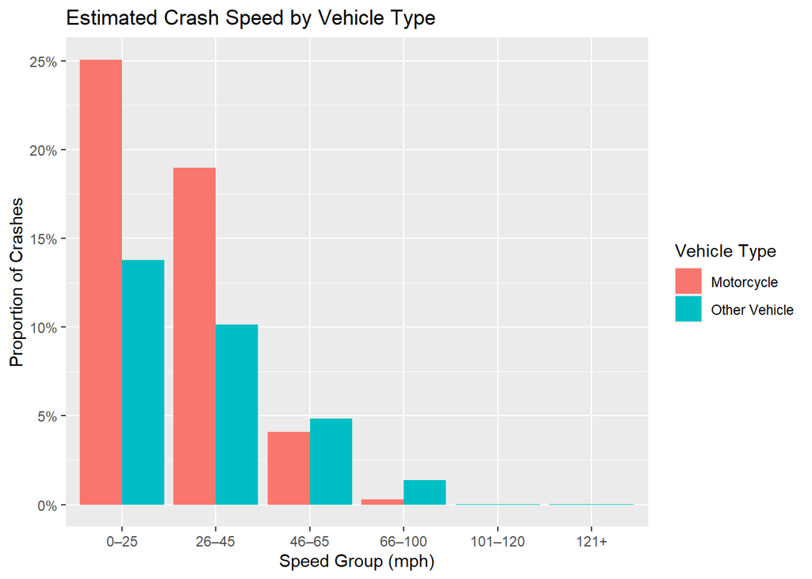

```r
 crash_data_speed <- crash_data_clean %>%
   filter(VSPD_LIM <= 95, !is.na(TRAV_SP) & TRAV_SP > 0 & TRAV_SP < 900 ) %>%
   mutate(
     SPEED_GROUP = cut(
       TRAV_SP,
       breaks = c(0, 25, 45, 65, 100,120, 900, Inf),
       labels = c("0–25", "26–45", "46–65", "66–100", "101–120", "121+", "Unknown"),
       right = TRUE
     )
   )

 speed_props <- crash_data_speed %>%
   group_by(VEHICLE_TYPE, SPEED_GROUP) %>%
   summarise(n = n(), .groups = "drop") %>%
   mutate(prop = case_when(
     VEHICLE_TYPE == "Motorcycle" ~ n / total_motorcycle,
     VEHICLE_TYPE == "Other Vehicle" ~ n / total_other
   ))

 ggplot(speed_props, aes(x = SPEED_GROUP, y = prop, fill = VEHICLE_TYPE)) +
   geom_col(position = "dodge") +
   labs(
     title = "Estimated Crash Speed by Vehicle Type",
     x = "Speed Group (mph)",
     y = "Proportion of Crashes",
     fill = "Vehicle Type"
   ) +
   scale_y_continuous(labels = scales::percent_format())
```

Here we see that for all the crashes where the speed before the crash was identified,the majority are low speed crashes. These might be single vehicle crashes or intersections, or low speed traffic collision.

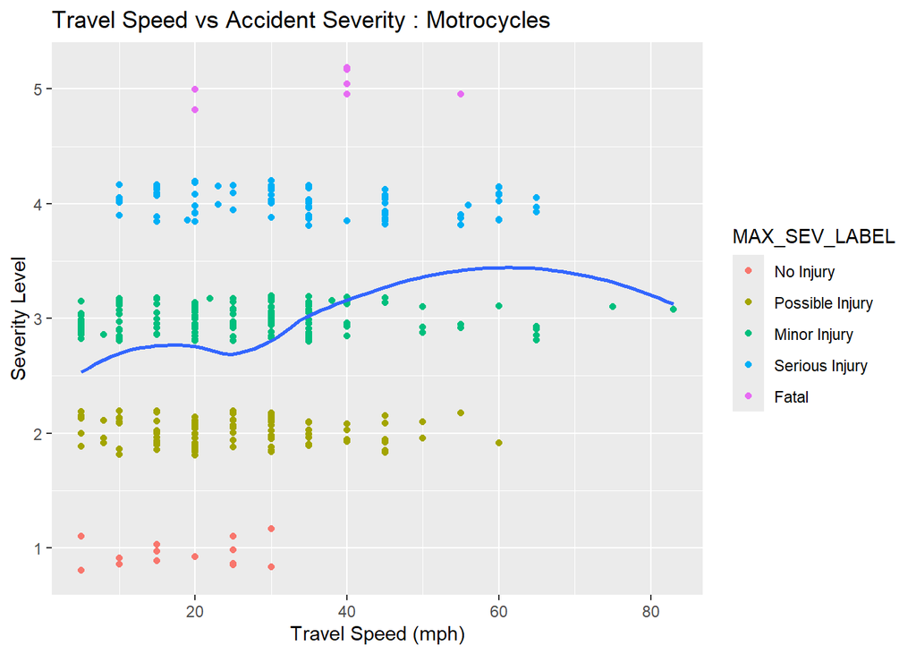

```r
 crash_data_speed_sampled <- crash_data_speed %>%
   filter (VEHICLE_TYPE == "Motorcycle") %>%
    mutate(
    Overspeed = TRAV_SP - VSPD_LIM
  )


 ggplot(crash_data_speed_sampled, aes(x = TRAV_SP, y = as.numeric(MAX_SEV_LABEL))) +
   geom_jitter(aes(color = MAX_SEV_LABEL), width = 0, height = 0.2) +
   geom_smooth(method = "loess", se = FALSE) +
   labs(
     title = "Travel Speed vs Accident Severity : Motrocycles ",
     x = "Travel Speed (mph)",
     y = "Severity Level"
   )
```

But when considering severity all of the non injury crashes where below 30 and severity increased as the speed increased.

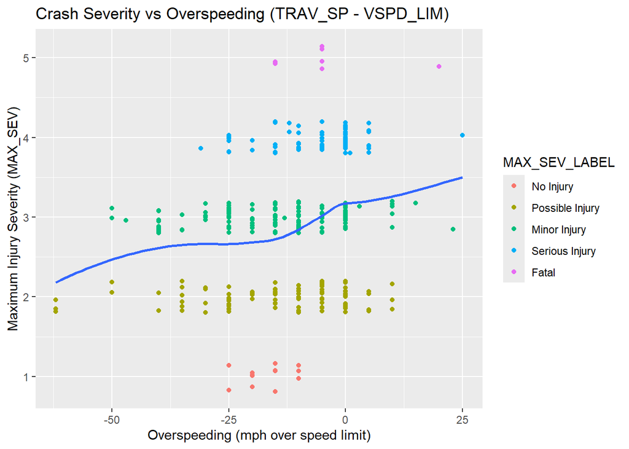

```r
ggplot(crash_data_speed_sampled, aes(x = Overspeed, y = as.numeric(MAX_SEV_LABEL))) +
  geom_jitter(aes(color = MAX_SEV_LABEL), width = 0, height = 0.2) +
geom_smooth(method = "loess", se = FALSE) +
  labs(
    title = "Crash Severity vs Overspeeding (TRAV_SP - VSPD_LIM)",
    x = "Overspeeding (mph over speed limit)",
    y = "Maximum Injury Severity (MAX_SEV)"
  )
```

##### Alchohol presence (Alchohol)

```
## # A tibble: 2 × 4
##   VEHICLE_TYPE ALCOHOL_LABEL        n   prop
##   <chr>        <fct>            <int>  <dbl>
## 1 Motorcycle   Alcohol Involved    28 0.0397
## 2 Motorcycle   No Alcohol         460 0.652
```

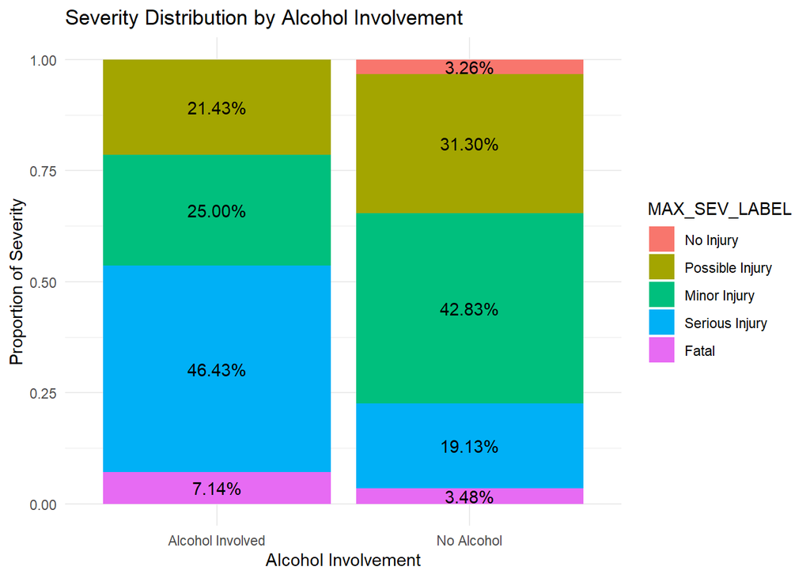

##### Helmet Usage (HELM_USE)

```
## # A tibble: 2 × 3
##   HELM_USE_LABEL     n  prop
##   <chr>          <int> <dbl>
## 1 DOT Helmet       202 0.598
## 2 No Helmet        136 0.402
```

Plotting

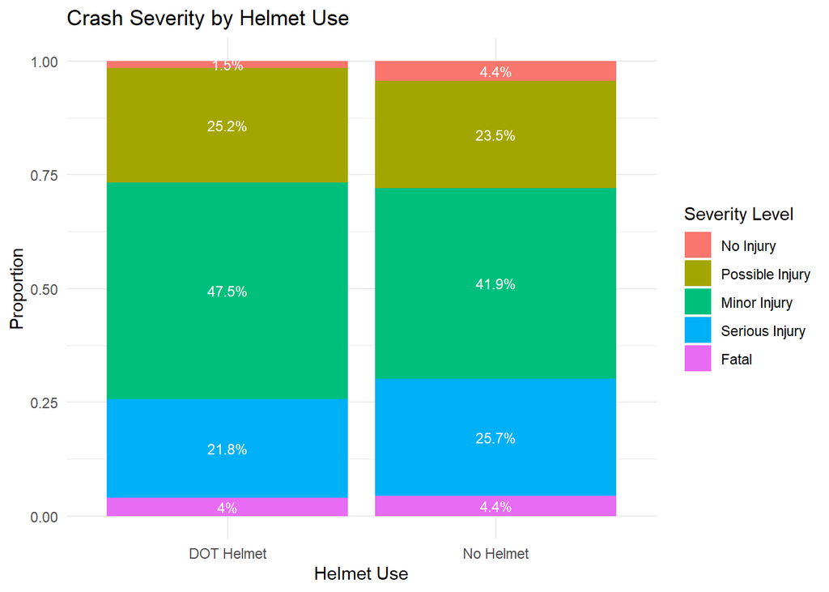

```r
crash_helm_pct <- crash_data_helm %>%
  count(HELM_USE_LABEL, MAX_SEV_LABEL) %>%
  group_by(HELM_USE_LABEL) %>%
  mutate(Percent = n / sum(n) * 100)

ggplot(crash_helm_pct, aes(x = HELM_USE_LABEL, y = Percent, fill = MAX_SEV_LABEL)) +
  geom_bar(stat = "identity", position = "fill") +
  geom_text(aes(label = paste0(round(Percent, 1), "%")),
            position = position_fill(vjust = 0.5), size = 3, color = "white") +
  labs(title = "Crash Severity by Helmet Use",
       x = "Helmet Use",
       y = "Proportion",
       fill = "Severity Level") +
  theme_minimal()
```

Splitting standards

```r
crash_data_helm_dot <- crash_data_clean %>%
  filter(VEHICLE_TYPE == "Motorcycle") %>%
  filter(HELM_USE %in% c(17, 5,16,19)) %>%
  mutate(
    HELM_USE_LABEL = case_when(
      HELM_USE %in% c(17) ~ "No Helmet",
      HELM_USE %in% c(5) ~ "DOT Helmet",
       HELM_USE %in% c(16,19) ~ "Unregulated Helmet",
      TRUE ~ "Unknown"
    )
  )

total_motorcycle_helm_dot <- crash_data_helm_dot %>% nrow()

helm_props_motorcycle_dot <- crash_data_helm_dot %>%
  group_by(HELM_USE_LABEL) %>%
  summarise(n = n(), .groups = "drop") %>%
  mutate(prop = n / total_motorcycle_helm_dot)

helm_props_motorcycle_dot
```

```
## # A tibble: 3 × 3
##   HELM_USE_LABEL         n  prop
##   <chr>              <int> <dbl>
## 1 DOT Helmet           127 0.376
## 2 No Helmet            136 0.402
## 3 Unregulated Helmet    75 0.222
```

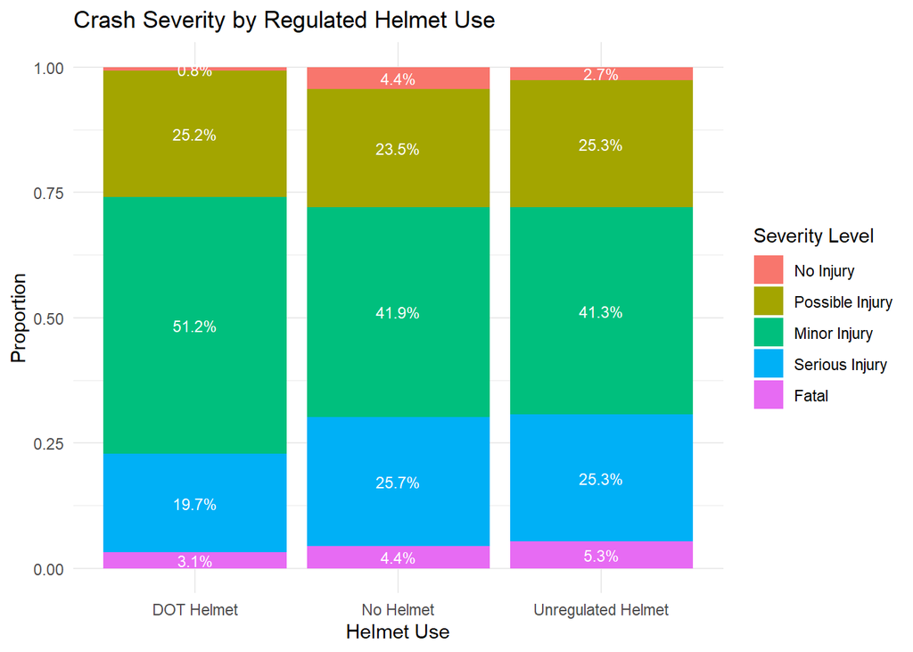

```r
crash_helm_pct_dot <- crash_data_helm_dot %>%
  count(HELM_USE_LABEL, MAX_SEV_LABEL) %>%
  group_by(HELM_USE_LABEL) %>%
  mutate(Percent = n / sum(n) * 100)

ggplot(crash_helm_pct_dot, aes(x = HELM_USE_LABEL, y = Percent, fill = MAX_SEV_LABEL)) +
  geom_bar(stat = "identity", position = "fill") +
  geom_text(aes(label = paste0(round(Percent, 1), "%")),
            position = position_fill(vjust = 0.5), size = 3, color = "white") +
  labs(title = "Crash Severity by Regulated Helmet Use",
       x = "Helmet Use",
       y = "Proportion",
       fill = "Severity Level") +
  theme_minimal()
```

##### Time of Day

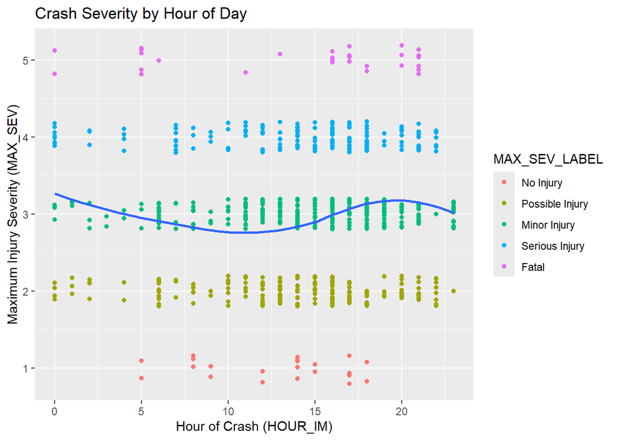

```r
crash_data_clean_motorcycle <- crash_data_clean %>%
  filter(VEHICLE_TYPE == "Motorcycle")

ggplot(crash_data_clean_motorcycle, aes(x = HOUR_IM, y = as.numeric(MAX_SEV_LABEL))) +
  geom_jitter(aes(color = MAX_SEV_LABEL), width = 0, height = 0.2) +
  geom_smooth(method = "loess", se = FALSE) +
  labs(
    title = "Crash Severity by Hour of Day",
    x = "Hour of Crash (HOUR_IM)",
    y = "Maximum Injury Severity (MAX_SEV)"
  )
```

#### Weather

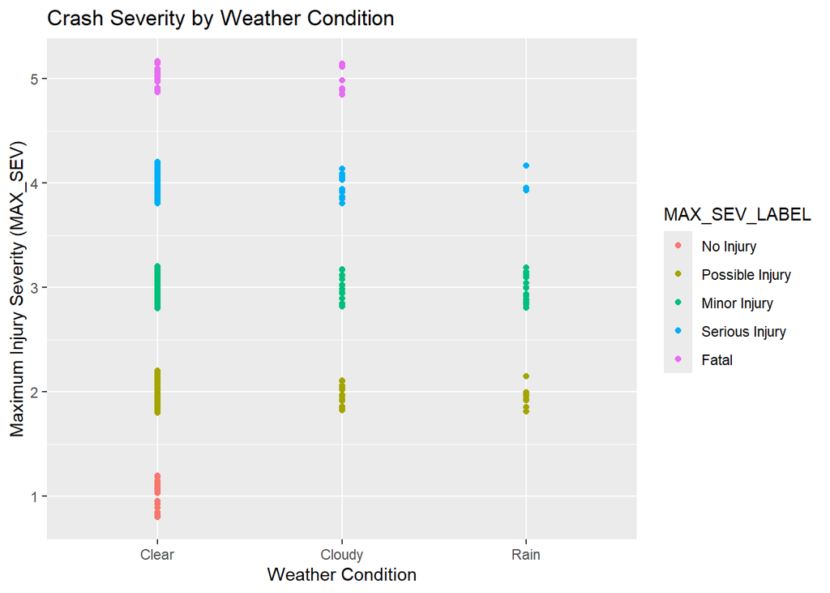

```r
crash_data_clean_weather <- crash_data_clean %>%
  filter(VEHICLE_TYPE == "Motorcycle") %>%
  mutate(
    Weather = case_when(
     WEATHR_IM == 1  ~ "Clear",
      WEATHR_IM == 2  ~ "Rain",
      WEATHR_IM == 4  ~ "Snow",
      WEATHR_IM == 5  ~ "Fog",
      WEATHR_IM == 6  ~ "Winds",
      WEATHR_IM == 7  ~ "Sandy",
      WEATHR_IM == 8  ~ "Other",
      WEATHR_IM == 10 ~ "Cloudy",
      WEATHR_IM == 11 ~ "Blowing Snow",
      WEATHR_IM == 12 ~ "Freezing Rain or Drizzle",
      TRUE ~ "Other/Unknown"
    ))


ggplot(crash_data_clean_weather, aes(x = Weather, y = as.numeric(MAX_SEV_LABEL))) +
 geom_jitter(aes(color = MAX_SEV_LABEL), width = 0, height = 0.2) +
  geom_smooth(method = "loess", se = FALSE) +
  labs(
    title = "Crash Severity by Weather Condition",
    x = "Weather Condition",
    y = "Maximum Injury Severity (MAX_SEV)"
  )
```

#### Multiple Regression model

```r
crash_data_combined <- crash_data_clean %>%
  filter(ALCOHOL %in% c(1, 2)) %>%
  filter(!is.na(TRAV_SP) & TRAV_SP > 0 & TRAV_SP < 900) %>%
  filter(!is.na(AGE), AGE <= 120) %>%
  mutate(
    ALCOHOL_LABEL = factor(
      ALCOHOL,
      levels = c(1, 2),
      labels = c("Alcohol Involved", "No Alcohol")
    ),

  ) %>%
  mutate(
    HELM_USE_LABEL = case_when(
      HELM_USE == 5 ~ "DOT Helmet",
      HELM_USE == 17 ~ "No Helmet"
    )
  ) %>%
 mutate(
    Overspeed = TRAV_SP - VSPD_LIM
  )
# Build the multiple regression model
model_combined <- lm(MAX_SEV ~ VEHICLE_TYPE + AGE + TRAV_SP + ALCOHOL_LABEL + HELM_USE_LABEL + HOUR_IM + Overspeed, data = crash_data_combined)

# Summarize the model
summary(model_combined)
```

```
##
## Call:
## lm(formula = MAX_SEV ~ VEHICLE_TYPE + AGE + TRAV_SP + ALCOHOL_LABEL +
##     HELM_USE_LABEL + HOUR_IM + Overspeed, data = crash_data_combined)
##
## Residuals:
##      Min       1Q   Median       3Q      Max
## -2.76448 -0.51875 -0.04095  0.66046  2.35281
##
## Coefficients:
##                            Estimate Std. Error t value Pr(>|t|)
## (Intercept)                1.922723   0.177026  10.861  < 2e-16 ***
## VEHICLE_TYPEOther Vehicle  0.287847   0.088522   3.252  0.00119 **
## AGE                       -0.002688   0.001810  -1.485  0.13776
## TRAV_SP                    0.007532   0.001786   4.217  2.7e-05 ***
## ALCOHOL_LABELNo Alcohol   -0.292170   0.097642  -2.992  0.00284 **
## HELM_USE_LABELNo Helmet   -0.073078   0.058048  -1.259  0.20835
## HOUR_IM                    0.014155   0.004629   3.058  0.00229 **
## Overspeed                  0.004039   0.001544   2.617  0.00900 **
## ---
## Signif. codes:  0 '***' 0.001 '**' 0.01 '*' 0.05 '.' 0.1 ' ' 1
##
## Residual standard error: 0.8416 on 1002 degrees of freedom
##   (51352 observations deleted due to missingness)
## Multiple R-squared:  0.107,  Adjusted R-squared:  0.1008
## F-statistic: 17.15 on 7 and 1002 DF,  p-value: < 2.2e-16
```

#### Conclusions

Analysis and insights will be presented in the Final project presentation.